# Analise exploratoria

### Aluno

Vinicius Souza Fialho Garcia, 15.1.8174

# Introdução

O objetivo deste pequeno teste prático é fazer uma análise inicial de uma base de dados com um histórico de preço de uma ação na bolsa de valores e de uma moeda.

## Dados iniciais

Nessa eatapa a base de dados foi carregada e as bibliotecas necessárias foram importadas, alem disso a função “summary” exibe uma exploração inicial dos dados trazendo algunas informaçoes como valor minimo, máximo, media e mediana, entre outros, sendo v2 Stock,e V3 Currency.

```r
rm(list = ls())
set.seed(123)
library("caret")
```

```r
library("som")
library("corrplot")
baseDados <- read.csv("C:/Users/Vini/Desktop/Teste Pratico/data.csv",header = FALSE,na.string="NA")

summary(baseDados)
```

```
##        V1              V2               V3
##  Min.   :    1   Min.   : 82.52   Min.   : 3.512
##  1st Qu.: 7525   1st Qu.: 86.79   1st Qu.: 8.677
##  Median :15058   Median : 94.05   Median :16.289
##  Mean   :15095   Mean   : 93.07   Mean   :15.450
##  3rd Qu.:22676   3rd Qu.: 96.18   3rd Qu.:21.748
##  Max.   :30243   Max.   :104.31   Max.   :26.369
```

## Relação temporal

Com a intenção de explorar a relação temporal entre os dados, foi feita uma normalização dos dados para posibilitar a geração de um gráfico que comparasse a evolução temporal dos memos.Podemos perceber que existe uma relação linear entre os dados, apesar de existirem descrepancias em alguns instantes de tempo.

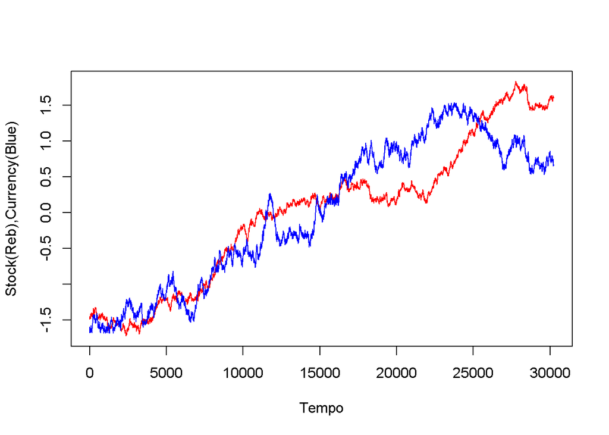

```r
baseDados2 <- som::normalize(baseDados,byrow = FALSE)

plot(baseDados[,1],baseDados2[,2],type = "l",col="red",ylab="Stock(Reb),Currency(Blue)",xlab="Tempo")
points(baseDados[,1],baseDados2[,3],type = "l",col="blue")
```

## Teste de Correlaçao

Nesta etapa, é exibido um teste de correlação entre os dados com a intenção de inticar o quão forte é a correlção de cada coluna, entendo assim como elas se afetam, sendo assim foi exibido um gráfico de coorrelação, e uma tabela entre cada coluna, alem disso foi realizado um Teste de Hipóteses (supondo que as suposições do teste sejam satisfeitas).Dado os resultados podemos observar que o tempo tem uma correlação linear muitor forte tanto com o stock como com o currency,e as 2 ultimas tem um correlção menor , porem considerável entre si, ou seja existe um padrão linear nos dados que pode ser explorado.E ainda o teste de hipotese nos mostra que Como o Valor P (p-value < 2.2e-16) é bem pequeno, conclui-se que o valor do Coeficiente de Correlação Linear de Pearson tem significância Estatística.

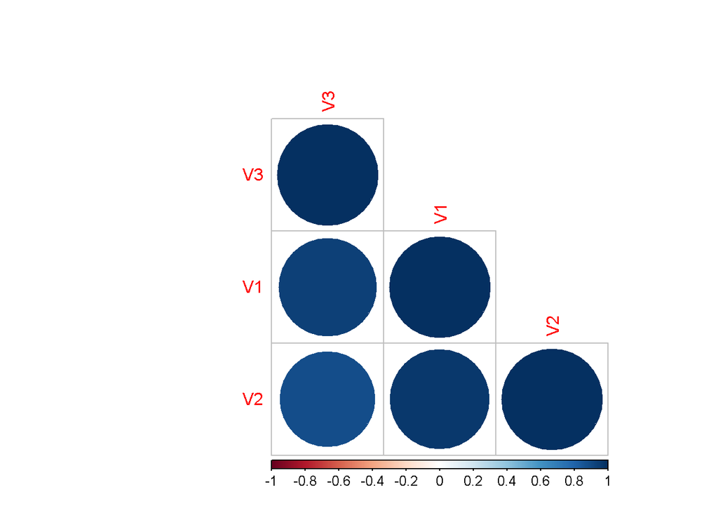

```r
correlationMatrix <- cor(baseDados)
corrplot(correlationMatrix, method="circle", type="lower", order="hclust")
```

```r
cor(baseDados)
```

```
##           V1        V2        V3
## V1 1.0000000 0.9684085 0.9332398
## V2 0.9684085 1.0000000 0.8839296
## V3 0.9332398 0.8839296 1.0000000
```

```r
cor.test(baseDados[,2],baseDados[,3])
```

```
##
##  Pearson's product-moment correlation
##
## data:  baseDados[, 2] and baseDados[, 3]
## t = 189.02, df = 9999, p-value < 2.2e-16
## alternative hypothesis: true correlation is not equal to 0
## 95 percent confidence interval:
##  0.8795684 0.8881423
## sample estimates:
##       cor
## 0.8839296
```

```r
cor.test(baseDados[,1],baseDados[,2])
```

```
##
##  Pearson's product-moment correlation
##
## data:  baseDados[, 1] and baseDados[, 2]
## t = 388.32, df = 9999, p-value < 2.2e-16
## alternative hypothesis: true correlation is not equal to 0
## 95 percent confidence interval:
##  0.9671662 0.9696046
## sample estimates:
##       cor
## 0.9684085
```

```r
cor.test(baseDados[,1],baseDados[,3])
```

```
##
##  Pearson's product-moment correlation
##
## data:  baseDados[, 1] and baseDados[, 3]
## t = 259.76, df = 9999, p-value < 2.2e-16
## alternative hypothesis: true correlation is not equal to 0
## 95 percent confidence interval:
##  0.9306631 0.9357239
## sample estimates:
##       cor
## 0.9332398
```

## BoxPlot

Com os dados ainda normalizados, é exibido a seguir o gráfico boxplot para representar a variação dos dados observados, podemos observar que grande parte dos dados tem uma concentração uniforte apesar das variações ja citadas, evidenciando ainda a aproximação existente entre os dados.

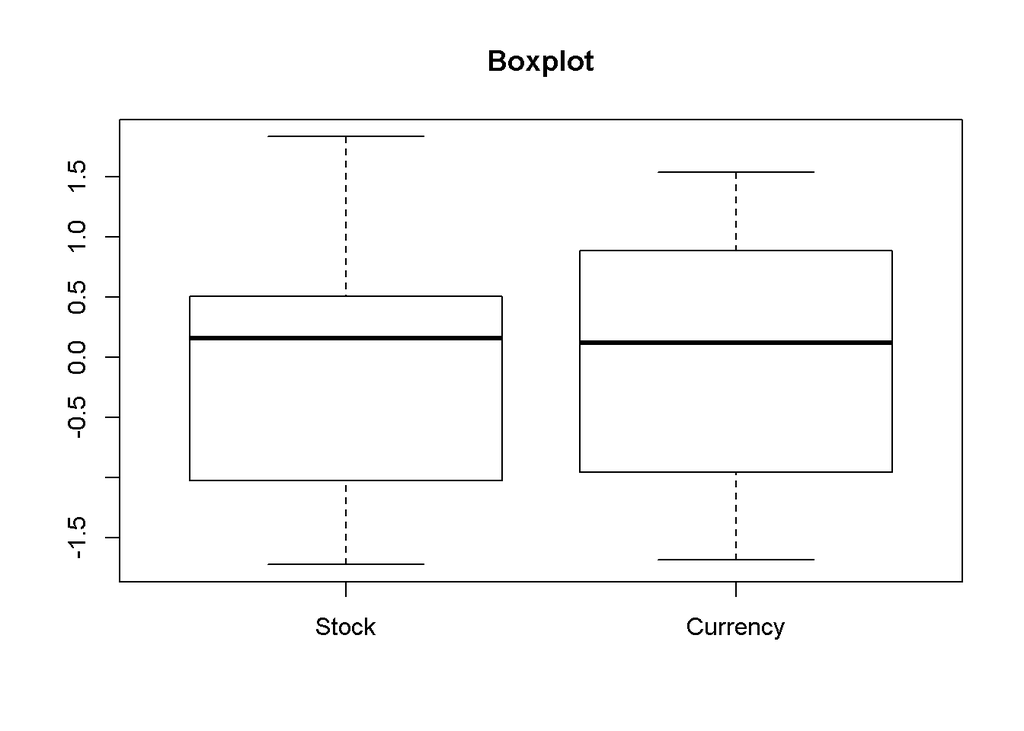

```r
boxplot(baseDados2[,2],baseDados2[,3],main="Boxplot",names=c("Stock","Currency"))
```

## Media, Desvio Padrao, e Variancia

Agora foram cauculadas a media, desvio padrao, e a variancia do Stock e currency, com o intuito de mostrar mais claramente a dispersão que existe entre os dados. Fica claro que existe um pequeno afastamento dos dados ao longo do tempo, porem isso acontece de maneira branda,entretanto deve-se estudar mais a fundo as medidas de dispersão dos dados para saber por que isso acontece.

```r
mean(baseDados[,2])
```

```
## [1] 93.07354
```

```r
mean(baseDados[,3])
```

```
## [1] 15.45039
```

```r
sd(baseDados[,2])
```

```
## [1] 6.118582
```

```r
sd(baseDados[,3])
```

```
## [1] 7.075205
```

```r
var(baseDados[,2])
```

```
## [1] 37.43705
```

```r
var(baseDados[,3])
```

```
## [1] 50.05852
```

## Diagrma de disperção

Como existe uma quantidade massiva de dados, para melhor representa - los grágicamente foi feita uma media dos mesmos a cada 100 instante de tempo.Logo em seguida é exibido o diagrama de dispersão e é usada a função “lm” para realizar a análise de variância.Fica evidente aqui, mais uma vez, que existe uma dispersão dos dados a partir de um certo momento,que deve ser estudada e entendida.

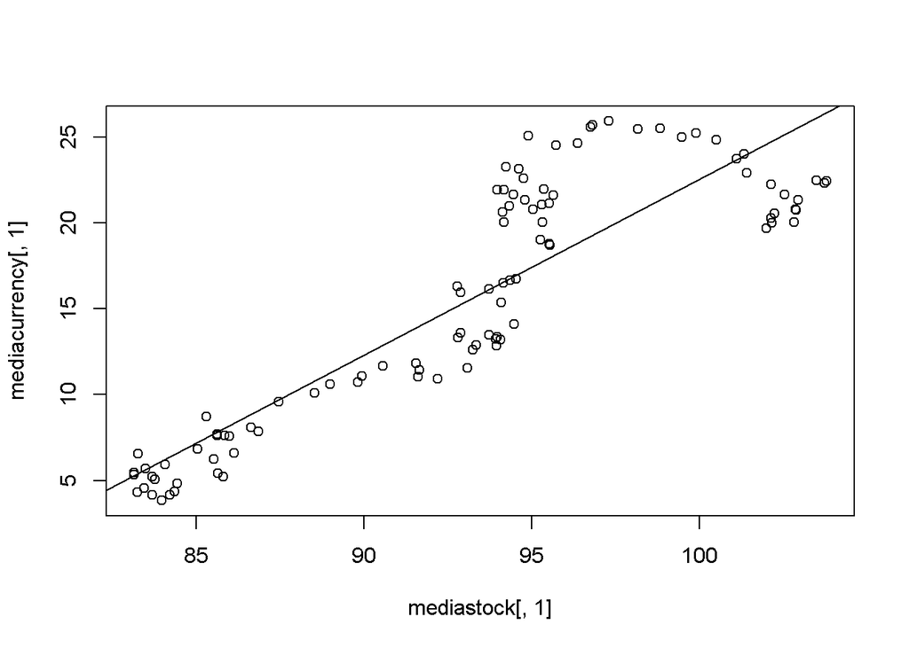

```r
mediastock= matrix(nrow = 100, ncol = 2)
mediacurrency = matrix(nrow = 100, ncol = 2)

b1 <- c()
b2 <- c()
n=0
for(i in 1:100){
  for(j in 1:100){

    b1[j]<-baseDados[n+j,2]
    b2[j]<-baseDados[n+j,3]
    }
  mediastock[i,1]<-mean(b1)
  mediastock[i,2]<-i
  mediacurrency[i,1]<-mean(b2)
  mediacurrency[i,2]<-i
  n=n+100
}



plot(mediastock[,1],mediacurrency[,1])
abline(lm(mediacurrency[,1] ~ mediastock[,1]))
```

## Ajuste do modelo linear

Existem muitos métodos disponíveis para inspecionar o resultado proposto pela função lm, entre eles o summary nos traz diversas informações interessante , pode-se obter, por exemplo, os erros-padrão (Std. Error) das estimativas dos coeficientes de regressão,Além disso obtém-se o valor do Coeficiente de Determinação (Multiple R-Squared), R2 = 0,786.O valor dos coeficientes de β0 e β1 sao estimados via Método de Mínimos Quadrados, exibidos atravez da variavel ajuste.

```r
ajuste=lm(mediastock[,1] ~ mediacurrency[,1])

print(ajuste)
```

```
##
## Call:
## lm(formula = mediastock[, 1] ~ mediacurrency[, 1])
##
## Coefficients:
##        (Intercept)  mediacurrency[, 1]
##            81.2116              0.7677
```

```r
summary(ajuste)
```

```
##
## Call:
## lm(formula = mediastock[, 1] ~ mediacurrency[, 1])
##
## Residuals:
##     Min      1Q  Median      3Q     Max
## -5.5443 -2.0776 -0.4158  1.7574  6.2312
##
## Coefficients:
##                    Estimate Std. Error t value Pr(>|t|)
## (Intercept)        81.21159    0.68727  118.17   <2e-16 ***
## mediacurrency[, 1]  0.76770    0.04046   18.97   <2e-16 ***
## ---
## Signif. codes:  0 '***' 0.001 '**' 0.01 '*' 0.05 '.' 0.1 ' ' 1
##
## Residual standard error: 2.856 on 98 degrees of freedom
## Multiple R-squared:  0.786,  Adjusted R-squared:  0.7839
## F-statistic:   360 on 1 and 98 DF,  p-value: < 2.2e-16
```

## Conclusão

Apesar de básica a analise exploratoria realizada, podemos concluir que existe sim um padrao de linearidade a ser explorado nos dados, entretanto é necessário estudar mais a fundo o problema e suas caracteristicas, para entendermos as dispersões existentes,se possivel aplicar metodos para minimiza-las e ou executar um metodo de regressão, por exemplo, para obter resultados satisfatorios.